# DATS 6101 Project 1

## 3. Normality Tests:

- QQ-plots: As expected from the relative frequency histograms, the QQ-plot for h closely follows the QQ-line (meaning that is follows a normal distribution), however the values clearly depart in that 0-20 million kilometer range. On the other hand, the nh data is clearly under dispersed, visualized by the s-shape in the QQ-plot, meaning that there is excess negative kurtosis in the subsetted data. Now, that we have looked at the visual component of these subsets, we thought it would be best to revisit the difference in the means to check if h and nh have the same sampling distribution for when it comes to `miss_distance`.

```r
#QQ-plots:
#For neo_h_tyler as a whole:
qqnorm(neo_h_tyler$miss_distance, col='red', main = 'QQ Plot for `miss_distance` of hazardous (n=2173)')
qqline(neo_h_tyler$miss_distance)
```

[figure not shown]

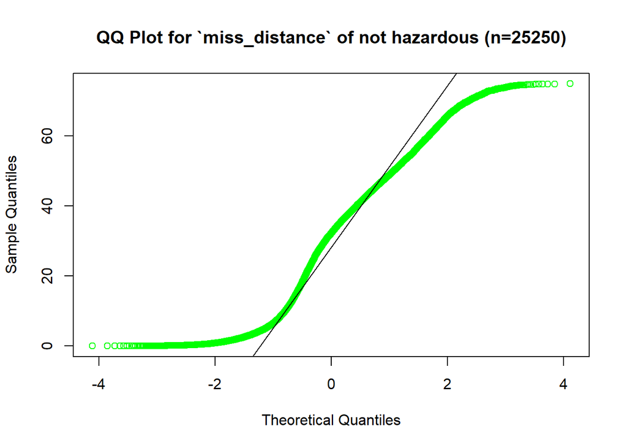

```r
#For neo_nh_tyler as a whole:
qqnorm(neo_nh_tyler$miss_distance, col='green', main = 'QQ Plot for `miss_distance` of not hazardous (n=25250)')
qqline(neo_nh_tyler$miss_distance)
```

```r
#Clearly under-dispersed data, or platykurtic distribution, having negative excess kurtosis.
```